# STA 141A Final Project

Siddhanth Sabharwal, 999229332 John Nguyen, 998808398

06/06/2017

###### Honor Code: The codes and results derived by using these codes constitute my own work. I have consulted the following resources regarding this assignment:

###### None

### Introduction

The data set chosen is a Twitter gender classification data set. The data set has information for 20,050 users across 26 variables. For these users the actual gender is given along with a probability level that the information is correct. Before training classification algorithms on this data, some data cleanup is required. First, all non-human users such as brands are removed. Second, users that can’t be determined to be humans are removed. Third, any user where Twitter wasn’t 100% confident about the gender was excluded so to not incorrectly train our algorithm.

#### Goals and Questions

For our project, we are trying to answer the following questions:

1. How well do words in tweets and profiles predict user gender?
2. What are the words that strongly predict male or female gender and what are the most popular words among them?
3. How well do stylistic factors (like link color and sidebar color) predict user gender?
4. How can we classify gender based on the user descriptions?

#### Data

Each row has a user name, a random tweet, account profile and image, location, and even link and sidebar color. The data Twitter User Gender Classification used for the project is available on Kaggle website. The data table includes 26 columns and 20,051 rows. Each row in the data represent a Twitter users, and the columns are are the data collected on the user. We also gather a data set of 100 common male and female names in the US to perform regular expression search on the username in order to deepen our classfication model for gender. The data is available on Social Security website.

##### Where our data points are coming from.

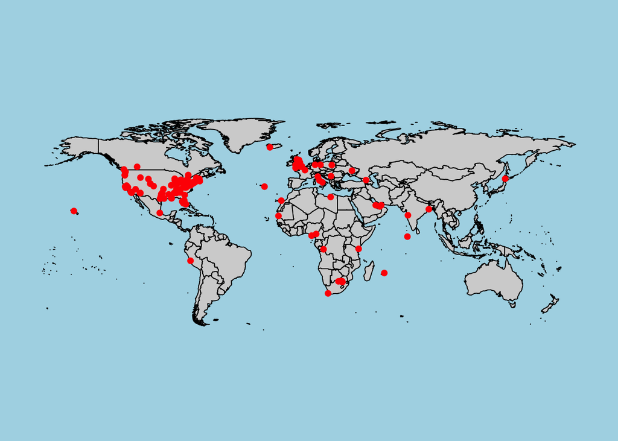

**The column labels are shown below:**

```
##  [1] "X_unit_id"      "gender"         "created"        "description"
##  [5] "fav_number"     "link_color"     "name"           "retweet_count"
##  [9] "sidebar_color"  "text"           "tweet_coord"    "tweet_count"
## [13] "tweet_location" "user_timezone"
```

#### Methods

For classification of the gender data, we use kNN and Naive Bayes methods. We also use graphs and plots to visualize the data. Using text column, we also find the frequency of top common words used in tweets based on gender and perform a clustering by Hierarchical Clustering using complete linkage